# Data Visualization on Honey Production dataset using seaborn and matplotlib libraries.

**Domain**: **Food and agriculture**

**Context:** **In 2006, a global concern was raised over the rapid decline in the honeybee population, an integral component to American honey agriculture. Large numbers of hives were lost to “Colony-Collapse-Disorder”, a phenomenon of disappearing “worker-bees” causing the remaining “hive-colony” to collapse. Speculation around the cause of this disorder points to hive-diseases and pesticides harming the pollinators, though no overall consensus has been reached. Twelve years later, some industries are observing recovery but the American honey industry is still largely struggling. The U.S. used to locally produce over half the honey it consumes per year. Now, honey mostly comes from overseas, with 350 of the 400 million pounds of honey consumed every year originating from imports. This dataset provides insight into honey production supply and demand in America by state from 1998 to 2012.**

**Objective:** **The Goal is to use Python visualization libraries such as seaborn and matplotlib to investigate the data and get some useful conclusions**

**1. Import required libraries and read the dataset**

```python
import pandas as pd
import numpy as np
import matplotlib.pyplot as plt
import seaborn as sns
import os
import warnings as wr
```

```python
wr.filterwarnings('ignore')
```

```python
os.getcwd()
```

```
'C:\\Users\\admin'
```

```python
df = pd.read_csv('honeyproduction.csv')
```

**2. Check the first few samples, shape, info of the data and try to familiarize yourself with different features.**

```python
df.head()
```

|  | state | numcol | yieldpercol | totalprod | stocks | priceperlb | prodvalue | year |
| --- | --- | --- | --- | --- | --- | --- | --- | --- |
| 0 | AL | 16000.0 | 71 | 1136000.0 | 159000.0 | 0.72 | 818000.0 | 1998 |
| 1 | AZ | 55000.0 | 60 | 3300000.0 | 1485000.0 | 0.64 | 2112000.0 | 1998 |
| 2 | AR | 53000.0 | 65 | 3445000.0 | 1688000.0 | 0.59 | 2033000.0 | 1998 |
| 3 | CA | 450000.0 | 83 | 37350000.0 | 12326000.0 | 0.62 | 23157000.0 | 1998 |
| 4 | CO | 27000.0 | 72 | 1944000.0 | 1594000.0 | 0.70 | 1361000.0 | 1998 |

```python
df.shape
```

```
(626, 8)
```

```python
df.info()
```

```
<class 'pandas.core.frame.DataFrame'>
RangeIndex: 626 entries, 0 to 625
Data columns (total 8 columns):
 #   Column       Non-Null Count  Dtype
---  ------       --------------  -----
 0   state        626 non-null    object
 1   numcol       626 non-null    float64
 2   yieldpercol  626 non-null    int64
 3   totalprod    626 non-null    float64
 4   stocks       626 non-null    float64
 5   priceperlb   626 non-null    float64
 6   prodvalue    626 non-null    float64
 7   year         626 non-null    int64
dtypes: float64(5), int64(2), object(1)
memory usage: 39.3+ KB
```

**3. Display the percentage distribution of the data in each year using the pie chart.**

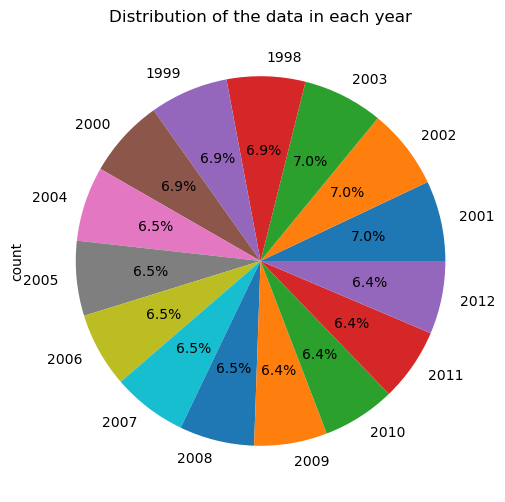

```python
plt.figure(figsize=(10,6))
df['year'].value_counts().plot(kind='pie',autopct='%1.1f%%')
plt.title('Distribution of the data in each year')
plt.show()
```

**4. Plot and Understand the distribution of the variable "price per lb" using displot, and write your findings.**

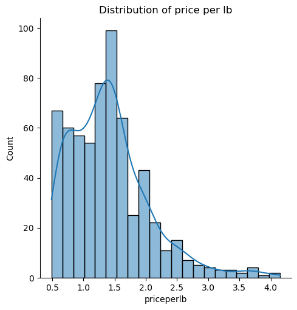

```
skewness of priceperlb is:  1.1941203818334443
```

```python
plt.figure(figsize=(12, 8))
sns.displot(data=df, x='priceperlb', kind='hist', kde=True)
plt.title('Distribution of price per lb')
plt.show()
print('skewness of priceperlb is: ',df['priceperlb'].skew())
```

**INFERENCE:**

**◉ The analysis of the 'price per lb' column reveals a right-skewed distribution, signifying that the majority of honey prices per pound tend to cluster towards the lower end of the scale. The presence of a longer right tail suggests occasional instances of higher-priced honey, potentially indicative of premium products or unique market dynamics.This may due to presence of outliers.**

**5. Plot and understand the relationship between the variables 'numcol' and 'prodval' through scatterplot, and write your findings.**

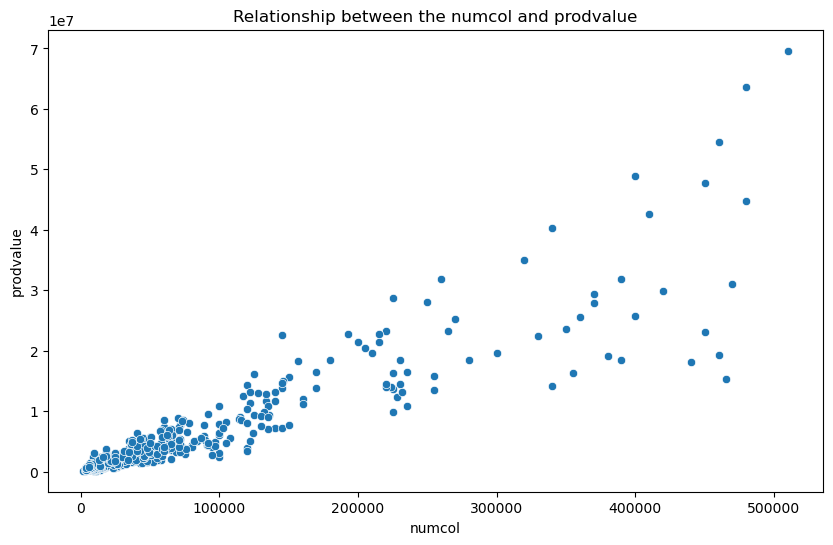

```python
plt.figure(figsize=(10,6))
sns.scatterplot(data=df,x= 'numcol',y= "prodvalue")
plt.title("Relationship between the numcol and prodvalue")
plt.xlabel('numcol')
plt.ylabel('prodvalue')
plt.show()
```

**INFERENCE:**

**◉ The scatterplot depicting the relationship between the number of honey-producing colonies ('numcol') and production value ('prodvalue') reveals a clear and positive linear trend. As the number of colonies increases, there is a corresponding rise in production value.**

**6. Plot and understand the relationship between categorical variable 'year' and a numerical variable 'prodvalue' through boxplot, and write your findings.**

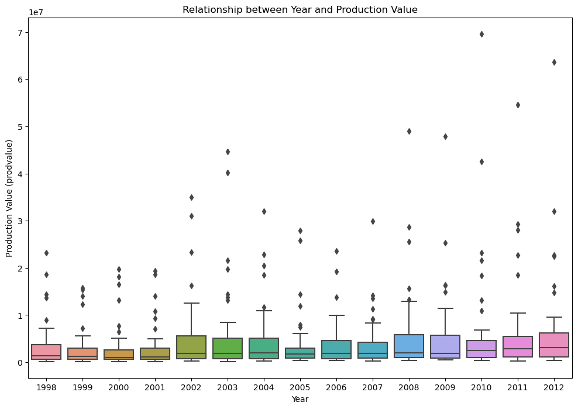

```python
plt.figure(figsize=(12, 8))
sns.boxplot(data=df, x='year', y='prodvalue')
plt.title('Relationship between Year and Production Value')
plt.xlabel('Year')
plt.ylabel('Production Value (prodvalue)')
plt.show()
```

**INFERENCE:**

**◉ While there is some variation, the overall trend suggests a positive relationship between year and production value.This aligns with the recovery observed in the honey industry after the Colony Collapse Disorder crisis.**

**7. Visualize and understand the relationship between the multiple pairs of variables throughout different years using pairplot and add your inferences. (use columns 'numcol', 'yield percol', 'total prod', 'prodvalue','year')**

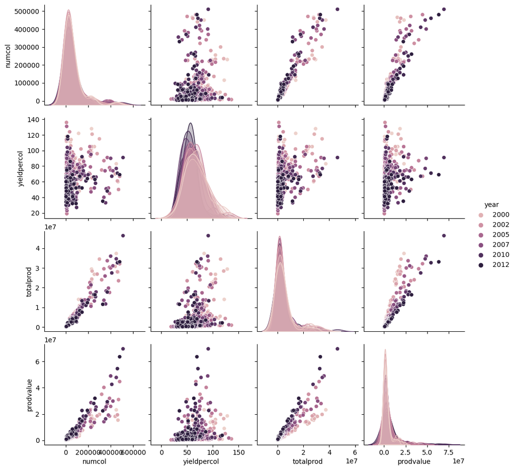

```python
a = ['numcol', 'yieldpercol', 'totalprod', 'prodvalue', 'year']
sns.pairplot(df[a], hue='year' )
plt.show()
```

**INFERENCE:**

**◉ See that prodvalue and numcol are positively correlated showing that increasing or decreasing the honey producing colonies impacting the Value of production by increasing or decreasing. From the histograms, we learn that the Totalprod and prodvalue variables are heavily right skewed.**

**8. Display the correlation values using a plot and add your inferences. (use columns 'numcol', 'yield percol', 'total prod', 'stocks', 'price per lb', 'prodvalue')**

```python
a =  df.drop(['state','year'],axis=1)
```

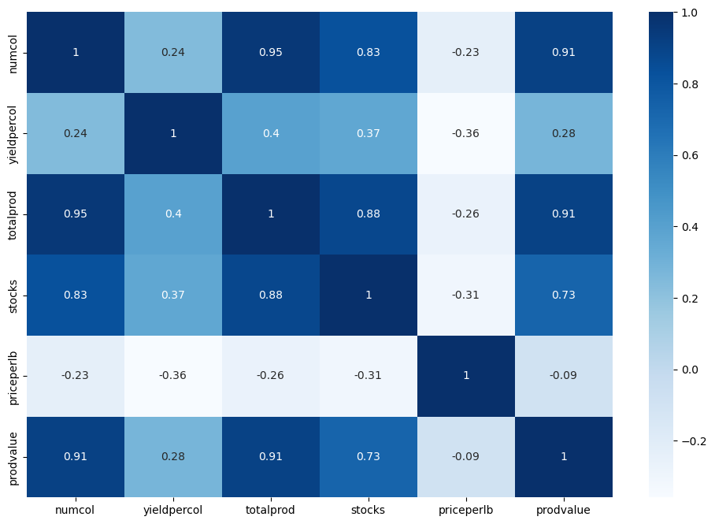

```python
plt.figure(figsize=(12,8))
sns.heatmap(data=a.corr(),annot=True,cmap='Blues')
plt.show()
```

**INFERENCE:**